# tema libre

britany gutierrez

2025-09-11

# Estrellas de mar

**¿Que son las estrellas de mar?**

Se conoce popularmente como estrellas de mar a una clase (Asteroidea) de seres vivos submarinos e invertebrados, pertenecientes al filo de los equinodermos (como los erizos de mar), cuyos cuerpos están formados por cinco o más brazos largos unidos a un disco central, otorgándoles así la apariencia de una estrella.

Se han identificado **hasta 1600 especies diferentes en esta misma clase de animales**, distribuidos a lo largo del mundo en distintos niveles de profundidad oceánica.

Se trata de uno de los habitantes más comunes y conocidos del suelo marino, que suelen aparecer en diversos tamaños y colores.

En la mayoría de las culturas humanas **se consideran seres atractivos**, inofensivos, que constituyen un símbolo de la vida marina y de las zonas costeras.

Muchas especies de estrellas de mar **se encuentran en riesgo de extinción por la destrucción de su hábitat**, como consecuencia de las actividades humanas en los océanos.

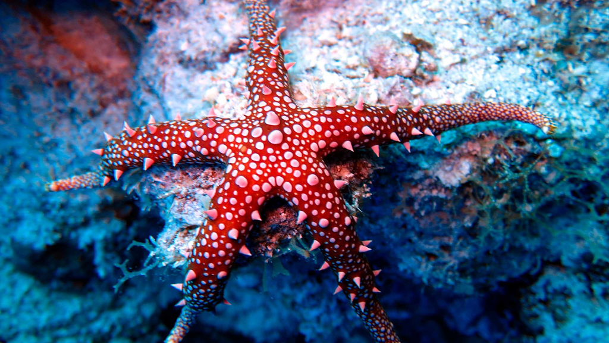

estrella de mar

# **Origen de las estrellas de mar**

La presencia de las estrellas de mar en el registro fósil, así como de otros invertebrados similares, no siempre es fácil de identificar, dado que sus partes blandas no se fosilizan bien y sus partes más rígidas se separan del resto cuando el animal se descompone.

Sin embargo, se estima que su origen evolutivo estaría en el período Ordovícico, en la Era Paleozoica, hace 485 millones de años aproximadamente.

Su mayor etapa de diversificación como especie estuvo entre el Jurásico Temprano y el Jurásico Medio, después de los eventos de extinción masiva durante el Devónico Tardío y el Pérmico Tardío, en los que la mayoría de las especies desaparecieron.

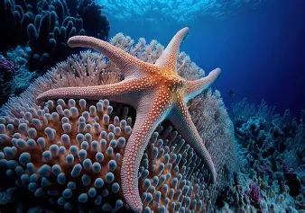

estrellas de mar

# **¿Dónde viven las estrellas de mar?**

Las estrellas de mar habitan los suelos oceánicos en el mundo entero, y son incapaces de subsistir en las aguas dulces. La mayor variedad de especies se halla en la región tropical del océano Indo-pacífico, y las de cinco brazos son las más predominantes de todas.

Se las puede observar hasta profundidades de 6 kilómetros por debajo de la superficie.

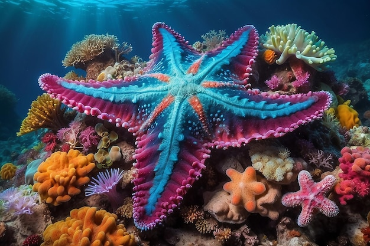

estrellas de mar

## conclusión

si logre poner imagenes.